# Quiz 5

Author

### Instructions

#### How to **complete** this assignment.

- Attempt each exercise in order.
- In each code chunk, if you see “# INSERT CODE HERE”, then you are expected to add some code to create the intended output (Make sure to erase “# INSERT CODE HERE” and place your code in its place).
- If my instructions say to “Run the code below…” then you do not need to add any code to the chunk.
- Many exercises may require you to type some text below the code chunk, interpreting the output and answering the questions.
- Please follow the rules from the course syllabus regarding seeking help with this assignment.

#### How to **submit** this assignment.

- When you are finished, click the “Render” button at the top of this panel. If there are no errors, an HTML file should pop up after a few seconds.
- Take a look at the resulting HTML file that pops up. Make sure everything looks correct, your name is listed at the top, and that there is no ‘junk’ code or output.
- Save the HTML file (to your local computer, and/or to a cloud location) as: **Quiz 5 “Insert Your Name”**.
- Before you upload the file to HuskyCT, you will need to zip/compress the file.
- Upload the problem set zipped/compressed HTML to HuskyCT. **Do not** upload the original .qmd version.
- This assignment is **due Monday, April 28, 2025, no later than 4:00 pm Eastern**. Points will be deducted for late submissions.
- TIP: Start early so that you can troubleshoot any issues with knitting to HTML.

#### Grading Rubric

There are 8 possible points on this assignment.

**Baseline (C level work)**

- Your .qmd file knits to HTML without errors.
- You answer questions correctly but do not use complete sentences.
- There are typos and ‘junk code’ throughout the document.
- You do not put much thought or effort into the Reflection answers.

**Average (B level work)**

- You use complete sentences to answer questions.
- You attempt every exercise/question.

**Advanced (A level work)**

- Your code is simple and concise.
- Unnecessary messages from R are hidden from being displayed in the HTML.
- Your document is typo-free.
- At the discretion of the instructor, you give exceptionally thoughtful or insightful responses.

##### **Exercise 1. (A) Download the appropriate libraries and packages (Hint: take special notice of the file extension for the `NC Counties` data (Hint: use `load()`)). (B) Using the `Covid April 14` and the `NC Counties` data, make a map of the cumulative number of confirmed cases, per capita, in each county in North Carolina. (3 points)**

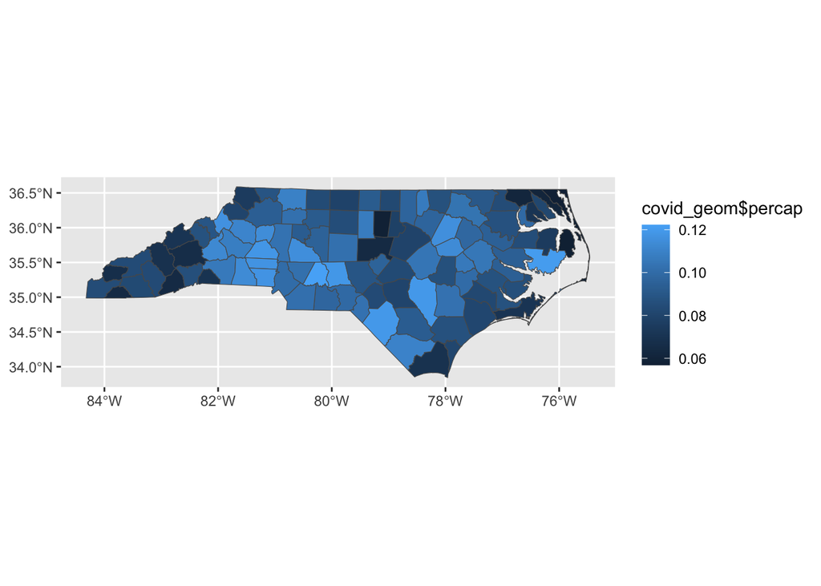

```r
#(A)
library(tidyverse)
library(sf)
library(tmap)

load("nc_counties.Rdata")
covid_april_14 <- read_csv("covid_hopkins_04-14-2021.csv")
#(B)
covid_geom <- nc_counties %>%
  mutate(GEOID = as.numeric(GEOID)) %>%
  left_join(covid_april_14, by=c("GEOID" = "FIPS")) %>%
  mutate(percap = Confirmed / estimate)


ggplot(data = covid_geom) +
  geom_sf(aes(fill = covid_geom$percap))
```

##### **Exercise 2. (A) Download the `Covid Data 1`. (B) Combine the `Covid Data 1` to the data frame that you created in Exercise 1. Next, create a variable that represents the number of confirmed cases that occurred from April 13 and April 14. Lastly, compute the confirmed per capita cases and visualize it in a map. (3 points)**

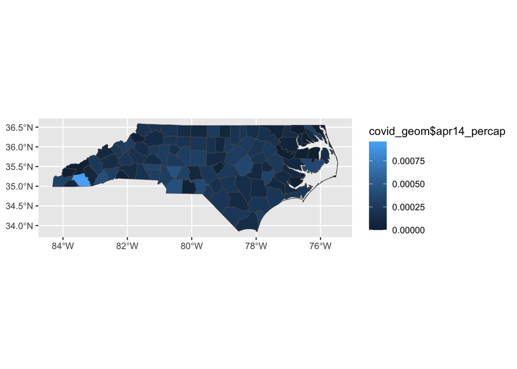

```r
#(A)
covid_april_13 <- read_csv("covid_hopkins_04-13-2021.csv")
#(B)
covid_geom <- covid_geom %>%
  left_join(covid_april_13, by=c("GEOID" = "FIPS")) %>%
  mutate(apr14diff = Confirmed.x - Confirmed.y,
         apr14_percap = apr14diff/estimate)


ggplot(data = covid_geom) +
  geom_sf(aes(fill = covid_geom$apr14_percap))
```

**ANSWER:**

##### **Exercise 3. (A) Utilize the `Covid April 14` and `US` data sets, make a map of the cumulative number of confirmed cases per capita, in each state in the United States. (2 points)**

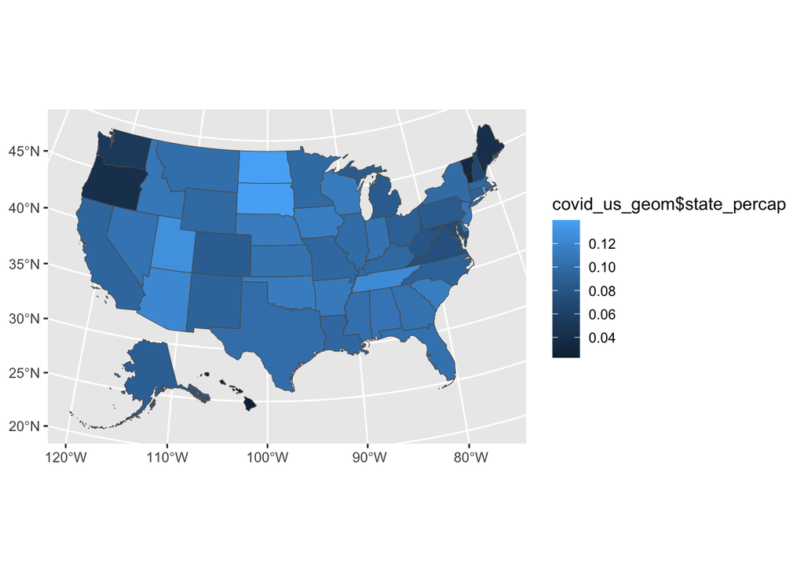

```r
load("us_geom.RData")



covid_state <- covid_april_14 %>%
  group_by(Province_State) %>%
  summarize(total = sum(Confirmed))



covid_us_geom <- us_geom %>%
  mutate(GEOID = as.numeric(GEOID)) %>%
  left_join(covid_state, by=c("NAME" = "Province_State")) %>%
  mutate(state_percap = total / estimate)


ggplot(data = covid_us_geom) +
  geom_sf(aes(fill = covid_us_geom$state_percap))
```

**ANSWER:**